# Credit Card Clustering Project

**Introduction**

Credit card companies generate large volumes of transactional data that reflect customer spending behavior, credit usage patterns, and repayment habits. However, this data is often underutilized when treated as a homogeneous population.

This project applies unsupervised machine learning techniques, specifically clustering algorithms, to segment credit card users into distinct behavioral groups based on their financial activity. The goal is to uncover hidden structure in the data without predefined labels and translate these patterns into actionable customer segments.

By analyzing features such as spending frequency, transaction amounts, credit utilization, and payment behavior, the model identifies groups of users with similar financial characteristics. These clusters can then be interpreted to support strategic decisions such as targeted marketing, credit risk assessment, customer retention strategies, and product personalization.

The project follows a standard data science workflow including data preprocessing, feature engineering, scaling, dimensionality reduction, clustering model selection, and cluster interpretation.

Ultimately, the objective is not only to build a clustering model, but to derive meaningful business insights from customer behavior patterns.

We begin by importing libraries to be used for loading and plotting the data.

```python
import numpy as np
import pandas as pd
import matplotlib.pyplot as plt
import seaborn as sns
%matplotlib inline
```

```python
df = pd.read_csv("https://raw.githubusercontent.com/mikedammy/data-science-portfolio/refs/heads/main/credit-card-clustering/cc_general.csv")
```

```python
df.columns = df.columns.str.lower()
df
```

|  | cust_id | balance | balance_frequency | purchases | oneoff_purchases | installments_purchases | cash_advance | purchases_frequency | oneoff_purchases_frequency | purchases_installments_frequency | cash_advance_frequency | cash_advance_trx | purchases_trx | credit_limit | payments | minimum_payments | prc_full_payment | tenure |
| --- | --- | --- | --- | --- | --- | --- | --- | --- | --- | --- | --- | --- | --- | --- | --- | --- | --- | --- |
| 0 | C10001 | 40.900749 | 0.818182 | 95.40 | 0.00 | 95.40 | 0.000000 | 0.166667 | 0.000000 | 0.083333 | 0.000000 | 0 | 2 | 1000.0 | 201.802084 | 139.509787 | 0.000000 | 12 |
| 1 | C10002 | 3202.467416 | 0.909091 | 0.00 | 0.00 | 0.00 | 6442.945483 | 0.000000 | 0.000000 | 0.000000 | 0.250000 | 4 | 0 | 7000.0 | 4103.032597 | 1072.340217 | 0.222222 | 12 |
| 2 | C10003 | 2495.148862 | 1.000000 | 773.17 | 773.17 | 0.00 | 0.000000 | 1.000000 | 1.000000 | 0.000000 | 0.000000 | 0 | 12 | 7500.0 | 622.066742 | 627.284787 | 0.000000 | 12 |
| 3 | C10004 | 1666.670542 | 0.636364 | 1499.00 | 1499.00 | 0.00 | 205.788017 | 0.083333 | 0.083333 | 0.000000 | 0.083333 | 1 | 1 | 7500.0 | 0.000000 | NaN | 0.000000 | 12 |
| 4 | C10005 | 817.714335 | 1.000000 | 16.00 | 16.00 | 0.00 | 0.000000 | 0.083333 | 0.083333 | 0.000000 | 0.000000 | 0 | 1 | 1200.0 | 678.334763 | 244.791237 | 0.000000 | 12 |
| ... | ... | ... | ... | ... | ... | ... | ... | ... | ... | ... | ... | ... | ... | ... | ... | ... | ... | ... |
| 8945 | C19186 | 28.493517 | 1.000000 | 291.12 | 0.00 | 291.12 | 0.000000 | 1.000000 | 0.000000 | 0.833333 | 0.000000 | 0 | 6 | 1000.0 | 325.594462 | 48.886365 | 0.500000 | 6 |
| 8946 | C19187 | 19.183215 | 1.000000 | 300.00 | 0.00 | 300.00 | 0.000000 | 1.000000 | 0.000000 | 0.833333 | 0.000000 | 0 | 6 | 1000.0 | 275.861322 | NaN | 0.000000 | 6 |
| 8947 | C19188 | 23.398673 | 0.833333 | 144.40 | 0.00 | 144.40 | 0.000000 | 0.833333 | 0.000000 | 0.666667 | 0.000000 | 0 | 5 | 1000.0 | 81.270775 | 82.418369 | 0.250000 | 6 |
| 8948 | C19189 | 13.457564 | 0.833333 | 0.00 | 0.00 | 0.00 | 36.558778 | 0.000000 | 0.000000 | 0.000000 | 0.166667 | 2 | 0 | 500.0 | 52.549959 | 55.755628 | 0.250000 | 6 |
| 8949 | C19190 | 372.708075 | 0.666667 | 1093.25 | 1093.25 | 0.00 | 127.040008 | 0.666667 | 0.666667 | 0.000000 | 0.333333 | 2 | 23 | 1200.0 | 63.165404 | 88.288956 | 0.000000 | 6 |

8950 rows × 18 columns

# Exploratory Data Analysis

In this section I explore the data, explain the columns, clean or impute missing values and visualize the data.

```python
df.info()
```

```
<class 'pandas.core.frame.DataFrame'>
RangeIndex: 8950 entries, 0 to 8949
Data columns (total 18 columns):
 #   Column                            Non-Null Count  Dtype
---  ------                            --------------  -----
 0   cust_id                           8950 non-null   object
 1   balance                           8950 non-null   float64
 2   balance_frequency                 8950 non-null   float64
 3   purchases                         8950 non-null   float64
 4   oneoff_purchases                  8950 non-null   float64
 5   installments_purchases            8950 non-null   float64
 6   cash_advance                      8950 non-null   float64
 7   purchases_frequency               8950 non-null   float64
 8   oneoff_purchases_frequency        8950 non-null   float64
 9   purchases_installments_frequency  8950 non-null   float64
 10  cash_advance_frequency            8950 non-null   float64
 11  cash_advance_trx                  8950 non-null   int64
 12  purchases_trx                     8950 non-null   int64
 13  credit_limit                      8949 non-null   float64
 14  payments                          8950 non-null   float64
 15  minimum_payments                  8637 non-null   float64
 16  prc_full_payment                  8950 non-null   float64
 17  tenure                            8950 non-null   int64
dtypes: float64(14), int64(3), object(1)
memory usage: 1.2+ MB
```

```python
df.describe().T[['mean', 'std', 'min', '50%', 'max']]
```

|  | mean | std | min | 50% | max |
| --- | --- | --- | --- | --- | --- |
| balance | 1564.474828 | 2081.531879 | 0.000000 | 873.385231 | 19043.13856 |
| balance_frequency | 0.877271 | 0.236904 | 0.000000 | 1.000000 | 1.00000 |
| purchases | 1003.204834 | 2136.634782 | 0.000000 | 361.280000 | 49039.57000 |
| oneoff_purchases | 592.437371 | 1659.887917 | 0.000000 | 38.000000 | 40761.25000 |
| installments_purchases | 411.067645 | 904.338115 | 0.000000 | 89.000000 | 22500.00000 |
| cash_advance | 978.871112 | 2097.163877 | 0.000000 | 0.000000 | 47137.21176 |
| purchases_frequency | 0.490351 | 0.401371 | 0.000000 | 0.500000 | 1.00000 |
| oneoff_purchases_frequency | 0.202458 | 0.298336 | 0.000000 | 0.083333 | 1.00000 |
| purchases_installments_frequency | 0.364437 | 0.397448 | 0.000000 | 0.166667 | 1.00000 |
| cash_advance_frequency | 0.135144 | 0.200121 | 0.000000 | 0.000000 | 1.50000 |
| cash_advance_trx | 3.248827 | 6.824647 | 0.000000 | 0.000000 | 123.00000 |
| purchases_trx | 14.709832 | 24.857649 | 0.000000 | 7.000000 | 358.00000 |
| credit_limit | 4494.449450 | 3638.815725 | 50.000000 | 3000.000000 | 30000.00000 |
| payments | 1733.143852 | 2895.063757 | 0.000000 | 856.901546 | 50721.48336 |
| minimum_payments | 864.206542 | 2372.446607 | 0.019163 | 312.343947 | 76406.20752 |
| prc_full_payment | 0.153715 | 0.292499 | 0.000000 | 0.000000 | 1.00000 |
| tenure | 11.517318 | 1.338331 | 6.000000 | 12.000000 | 12.00000 |

## Data Understanding

There are 8950 instances (rows) and 18 columns in the dataset.

```python
df['minimum_payments'] = df['minimum_payments'].fillna(0)
df['credit_limit'] = df['credit_limit'].fillna(df['credit_limit'].median())
```

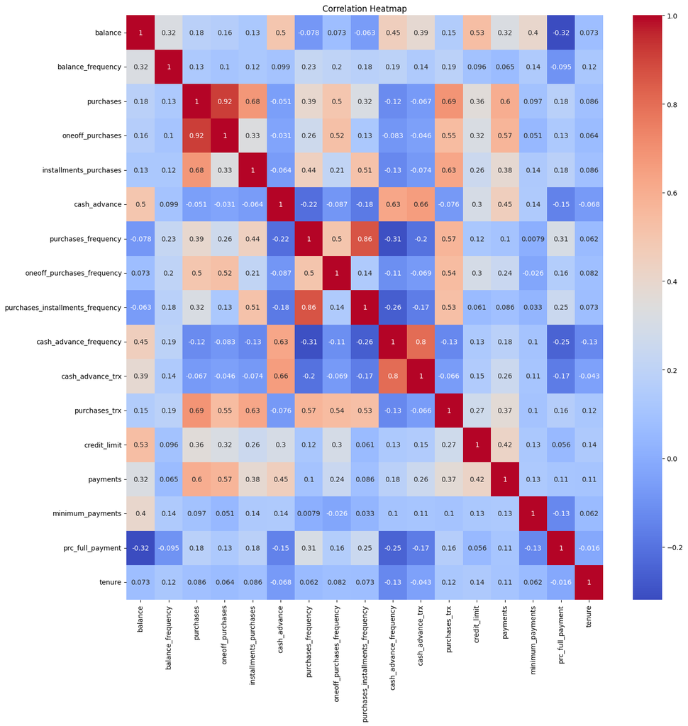

```python
corr_df = df.corr(numeric_only=True)

plt.figure(figsize=(15, 15))
sns.heatmap(
    data=corr_df,
    annot=True,
    cmap='coolwarm'
)

plt.title("Correlation Heatmap")
plt.savefig('corrrelation_heatmap.png')
plt.tight_layout()
```

## Correlation Heatmap Interpretation

The correlation heatmap helps identify which features contain similar information (are highly corrrlated) and which ones provide unique signals (have low correlation). This is important because K-Means clustering, which will be used in this project, is distance-based, so highly correlated variables can over-emphasize certain behaviors.

1. **Highly Correlated Features (Redundant Information)**

Some features move closely together, meaning they describe the same behavior:

- **Purchases and Oneoff Purchases** Total spending is largely driven by single large purchases. These two features carry very similar information.
- **Purchases Frequency and Installments Related Features** Frequent shoppers tend to use installment payments more often, showing a link between usage frequency and credit-based spending.
- **Cash Advance and Cash Advance Trx** Customers who take cash advances often do so repeatedly, not as one-time behavior.

**Interpretation:**

These variables overlap and represent the same underlying customer behavior. If not handled properly, they can bias the clustering model.

2. **Weakly Correlated Features (Independent Signals)**

Some variables do not strongly relate to others:

- **Tenure**: Customer duration is not strongly linked to spending or repayment patterns.
- **Credit Limit vs usage features** Having a high credit limit does not guarantee high spending or activity.

**Interpretation** These features provide separate information and help define different customer types.

3. **Risk and Payment Behavior**

Some relationships show financial behavior patterns:

- **Balance and Cash Advance** Customers with higher balances are more likely to take cash advances, which can signal financial pressure.
- **Payments and Purchases** People who spend more also pay more, but not always fully or consistently.
- **Prc Full Payment** Shows how often customers fully clear their balance, separating disciplined users from those who carry debt.

**Summary**

The dataset contains overlapping spending features, independent behavioral features, and credit-risk-related features. If used directly, correlated variables may distort clustering results.

**Decision**

No features will be dropped at this stage. Instead, PCA will be used later to:

- reduce correlation effects,
- combine related features into components, and
- simplify the dataset while keeping all information.

This ensures clustering is done on a cleaner and more balanced feature space.

# Data Preprocessing

Next I drop any variable that won't be uses towards the analysis, then I scale the data to ensure the K-Means algorithm treats all variable with equal weight.

The scaling technique I use is the Robust Scaler due to it's ability to handle outliers better than the Standard Scaler.

The Robust Scaler is calculated by subtracting the median from each data point and dividing it by the IQR.

The mathematical formula for the **Robust Scaler** is:

$$X_{scaled} = \frac{X_i - \text{median}(X)}{IQR}$$

Where:

- **$X_i$**: The individual data point.
- **$\text{median}(X)$**: The 50th percentile ($Q_2$), which is less sensitive to outliers than the mean.
- **$IQR$**: The Interquartile Range ($Q_3 - Q_1$), representing the middle 50% of the data.

```python
from sklearn.preprocessing import RobustScaler

df.drop('cust_id', axis=1, inplace=True)

scaler = RobustScaler()

df_scaled = scaler.fit_transform(df)
```

# Principal Component Analysis (PCA)

Principal Component Analysis is a dimensionality reduction technique used to transform a large set of variables into a smaller one that still contains most of the information (variance) from the original dataset.

Why PCA is used in this project:

- **Handling Multicollinearity:** As seen in our correlation heatmap, several features are highly redundant. PCA creates new, uncorrelated features called Principal Components.
- **Reducing Noise**: By focusing on the components that capture the most variance, we can filter out minor fluctuations (noise) that might confuse the clustering algorithm.
- **Optimizing K-Means:** K-Means performs better in lower-dimensional spaces, as high dimensionality can cause all data points to appear equidistant (the "Curse of Dimensionality").

I will apply PCA to the scaled data to reduce the 17 behavioral features into a smaller subset of components. I will determine the optimal number of components by analyzing the Explained Variance Ratio, ensuring we retain at least 90-95% of the original information.

```python
from sklearn.decomposition import PCA

pca = PCA()
pca.fit(df_scaled)
```

```
PCA()
```

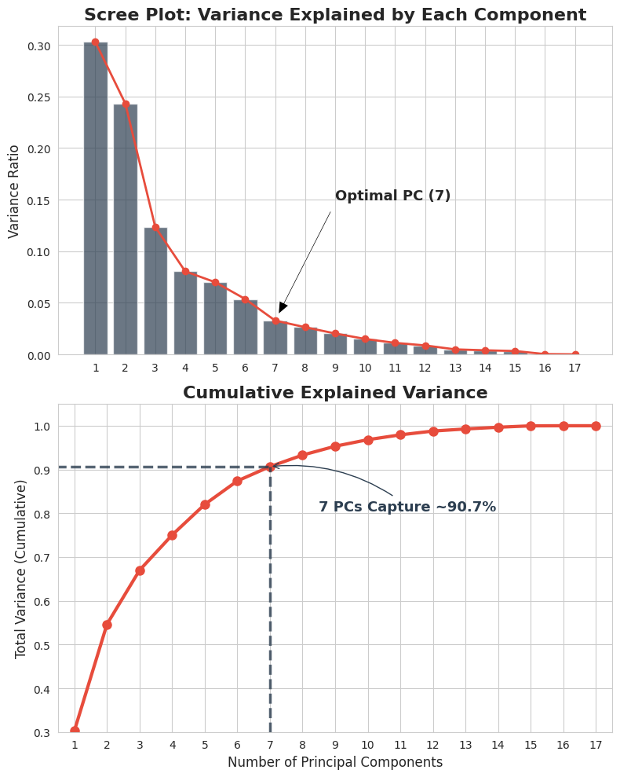

```python
cum_variance = np.cumsum(pca.explained_variance_ratio_)

sns.set_style("whitegrid")
fig, (ax1, ax2) = plt.subplots(2, 1, figsize=(8, 10))
plt.subplots_adjust(hspace=0.4)

ax1.bar(range(1, 18), pca.explained_variance_ratio_, color='#2c3e50', alpha=0.7, label='Individual Variance')
ax1.plot(range(1, 18), pca.explained_variance_ratio_, marker='o', color='#e74c3c', linewidth=2)

ax1.annotate('Optimal PC (7)', xy=(7, pca.explained_variance_ratio_[6]),
             xytext=(9, 0.15),
             arrowprops=dict(facecolor='black', shrink=0.05, width=1.5, headwidth=10),
             fontsize=13, fontweight='bold')

ax1.set_title('Scree Plot: Variance Explained by Each Component', fontsize=16, fontweight='bold')
ax1.set_ylabel('Variance Ratio', fontsize=12)
ax1.set_xticks(range(1, 18))

ax2.plot(range(1, 18), cum_variance, marker='o', color='#e74c3c', linewidth=3, markersize=8)

target_variance = cum_variance[6]
ax2.vlines(x=7, ymin=0.3, ymax=target_variance, color='#2c3e50', linestyle='--', linewidth=2.5, alpha=0.8)
ax2.hlines(xmin=0, xmax=7, y=target_variance, color='#2c3e50', linestyle='--', linewidth=2.5, alpha=0.8)

ax2.annotate(f'7 PCs Capture ~{target_variance:.1%}',
             xy=(7, target_variance),
             xytext=(8.5, target_variance - 0.1),
             fontsize=13, fontweight='bold', color='#2c3e50',
             arrowprops=dict(arrowstyle="->", connectionstyle="arc3,rad=.2", color='#2c3e50'))

ax2.set_title('Cumulative Explained Variance', fontsize=16, fontweight='bold')
ax2.set_xlabel('Number of Principal Components', fontsize=12)
ax2.set_ylabel('Total Variance (Cumulative)', fontsize=12)
ax2.set_xticks(range(1, 18))
ax2.set_xlim(0.5, 17.5)
ax2.set_ylim(0.3, 1.05)
plt.tight_layout()
#plt.savefig('pca_final_selection.png', dpi=300, bbox_inches='tight')
plt.show()
```

## Scree Plot Interpretation

Haven scaled the data and applying the PCA for dimensionality reduction, above are the scree plot and the cumulative explained variance plot.

**Scree Plot Analysis (Individual Variance)**

The Scree Plot illustrates the variance captured by each individual Principal Component. We observe a sharp decline in explained variance after the first three components. A visible "elbow" or point of diminishing returns occurs around Component 7, after which the incremental information gained by adding further components becomes marginal.

**Cumulative Variance Threshold**

To quantify the trade-off between simplicity and data integrity, I analyzed the Cumulative Explained Variance:

By selecting 7 Principal Components, we successfully capture 90% of the original dataset’s total variance.

This represents a 60% reduction in dimensionality (from 17 to 7 features) while maintaining a high level of informational accuracy.

**Conclusion**

Selecting 7 components ensures that the subsequent K-Means algorithm is not misled by redundant features or high-dimensional "noise." This curated feature space provides a robust foundation for identifying distinct customer segments based on their primary financial behaviors (e.g., high-volume spending vs. cash-advance dependency).

```python
pca7 = PCA(n_components=7)
pca7.fit(df_scaled)

pca_data = pca7.fit_transform(df_scaled)

pca_df = pd.DataFrame(
    pca_data, columns=[f'PC{i}' for i in range(1, 8)]
)

pca_df
```

|  | PC1 | PC2 | PC3 | PC4 | PC5 | PC6 | PC7 |
| --- | --- | --- | --- | --- | --- | --- | --- |
| 0 | -2.577045 | -0.009110 | -0.937097 | 0.261604 | -1.208139 | 0.472606 | 0.596663 |
| 1 | -0.274706 | 1.822354 | 3.848629 | -1.451908 | 1.439265 | -0.788678 | 1.564943 |
| 2 | -0.169419 | -0.319025 | -0.530308 | 1.859253 | -1.486442 | -0.649758 | 0.512912 |
| 3 | -0.848363 | -1.465373 | -0.570487 | -1.348637 | -2.743407 | 0.200658 | 0.251750 |
| 4 | -2.189738 | 0.247630 | -0.465498 | 1.585156 | -1.004209 | -0.223457 | 0.770274 |
| ... | ... | ... | ... | ... | ... | ... | ... |
| 8945 | -2.201116 | -0.889876 | -1.452271 | 0.267426 | 1.844805 | -1.780500 | -4.600868 |
| 8946 | -2.379661 | -0.287564 | -0.574285 | 1.219111 | -0.600879 | 0.159973 | -4.547966 |
| 8947 | -2.664954 | -0.485843 | -1.292972 | -0.591506 | 0.151086 | -0.594759 | -4.575430 |
| 8948 | -2.954917 | -0.225164 | -0.675314 | -0.813616 | -0.093591 | -0.976155 | -4.715369 |
| 8949 | -1.106504 | -1.311453 | -0.405877 | -1.396505 | -2.221636 | 0.105955 | -5.279816 |

8950 rows × 7 columns

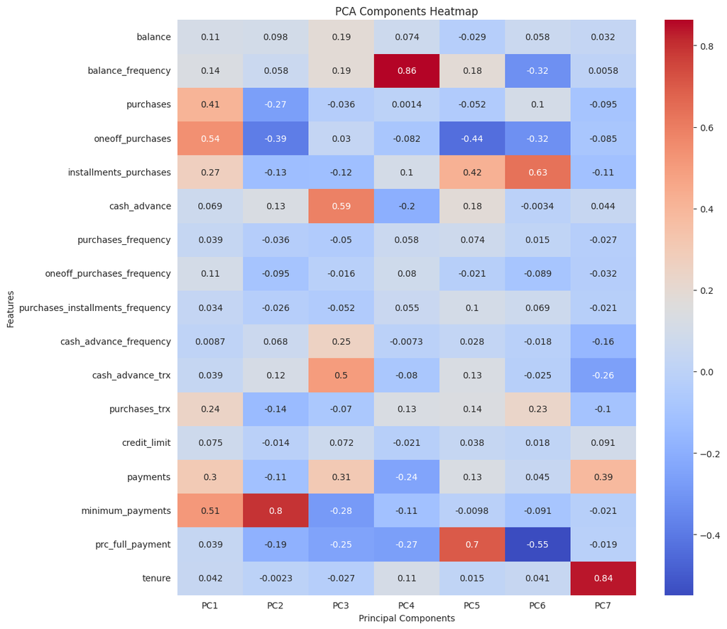

```python
components_df = pd.DataFrame(
    pca7.components_, columns=df.columns
).T

components_df.columns = [f'PC{i}' for i in range(1, 8)]

plt.figure(figsize=(12, 10))
sns.heatmap(
    data=components_df,
    annot=True,
    cmap='coolwarm',
    #center=0
)

plt.title("PCA Components Heatmap")
plt.ylabel("Features")
plt.xlabel("Principal Components")
plt.tight_layout()

plt.savefig('pca_heatmap.png', dpi=300)
plt.show()
```

## **PCA Loadings Interpretation: Decoding the Principal Components**

While PCA reduces dimensionality, it creates abstract components that can be difficult to interpret. By analyzing the **Loadings Heatmap**, we can see which original features contribute most to each Principal Component (PC). This allows us to assign "human" labels to these dimensions before feeding them into the K-Means algorithm.

### **Conclusion for Clustering**

# K-Means Clustering Algorithm

The next step is to initialize the k-means clustering algorithm to cluster the decomposed data. The k-means clustering algorithm is selected because it is an efficient, distance-based unsupervised learning method that excels at partitioning data into distinct, non-overlapping subgroups.

For this project, K-Means is specifically chosen because:

- **Computational Efficiency**: It handles large datasets, like our credit card records, much faster than hierarchical clustering methods.
- **Compatibility with PCA**: K-Means relies on Euclidean distance. Since PCA has already centered our data and removed multicollinearity, the "distance" between points in the 7D component space now has a much clearer behavioral meaning.
- **Actionable Segmentation**: It forces every customer into exactly one cluster, which is ideal for creating clear-cut marketing strategies (e.g., specific campaigns for "Power Spenders" vs. "Cash-Advance Users").

**Determining the Number of Clusters (K)**

To find the optimal number of clusters, I use a two-pronged approach to ensure the segments are mathematically sound and practically useful:

1. **The Elbow Method (WCSS)**: I plot the Within-Cluster Sum of Squares for a range of k values. We are looking for the "elbow" where the drop in WCSS slows down, indicating that adding more clusters provides diminishing returns in explaining the data's variance.
2. **Silhouette Score Analysis**: To validate the elbow, I calculate the Silhouette Score, which measures how similar a point is to its own cluster compared to other clusters. A higher score indicates well-defined, separated segments.

```python
from sklearn.cluster import KMeans
from sklearn.metrics import silhouette_score
```

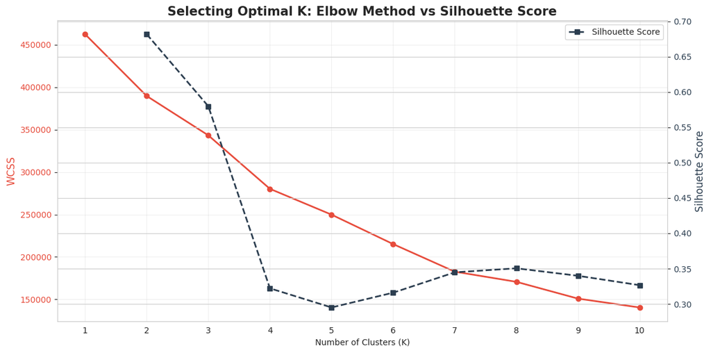

```python
k_range = np.arange(1, 11)
wcss = []
silhouette_scores = []

for k in k_range:
    kmeans = KMeans(n_clusters=k, random_state=42)
    kmeans.fit(pca_df)
    wcss.append(kmeans.inertia_)

# 1. Calculate Silhouette Scores (Start from 2 clusters)
silhouette_avg = []
k_range_sil = range(2, 11)

for k in k_range_sil:
    kmeans = KMeans(n_clusters=k, random_state=42, n_init=10)
    labels = kmeans.fit_predict(pca_df)
    silhouette_avg.append(silhouette_score(pca_df, labels))

# 2. Plotting side-by-side
fig, ax1 = plt.subplots(figsize=(12, 6))

# Plot WCSS (Elbow)
ax1.set_xlabel('Number of Clusters (K)')
ax1.set_ylabel('WCSS', color='#e74c3c', fontsize=12)
ax1.plot(range(1, 11), wcss, marker='o', color='#e74c3c', linewidth=2, label='WCSS (Elbow)')
ax1.tick_params(axis='y', labelcolor='#e74c3c')
ax1.grid(True, alpha=0.3)

# Create a second y-axis for Silhouette Score
ax2 = ax1.twinx()
ax2.set_ylabel('Silhouette Score', color='#2c3e50', fontsize=12)
ax2.plot(k_range_sil, silhouette_avg, marker='s', color='#2c3e50', linewidth=2, linestyle='--', label='Silhouette Score')
ax2.tick_params(axis='y', labelcolor='#2c3e50')

plt.title('Selecting Optimal K: Elbow Method vs Silhouette Score', fontsize=15, fontweight='bold')
plt.xticks(range(1, 11))

plt.tight_layout()
plt.legend(loc='best')
plt.savefig("selecting_k.png", dpi=300)
plt.show()
```

## Determining Optimal K: A Multi-Metric Approach

The selection of the number of clusters (K) is a critical decision that balances mathematical cohesion with practical business utility. To ensure the most robust segmentation, I utilized a dual-validation approach using the Elbow Method (WCSS) and Silhouette Analysis.

1. **The Elbow Method (WCSS) Analysis**

The WCSS plot shows a primary inflection point (the "Elbow") at K=4, where the rate of decrease in within-cluster variance begins to slow. In many basic analyses, K=4 would be the default choice. However, a secondary, more subtle "shelf" appears between K=7 and K=8, suggesting that further partitioning might still yield meaningful behavioral separation.

2. **Silhouette Score Validation**

To resolve the ambiguity of the Elbow plot, I analyzed the Silhouette Score, which measures cluster separation and individual point belonging.

```python
kmeans = KMeans(n_clusters=8, random_state=42, n_init=10)
kmeans.fit(pca_df)

pca_df['cluster'] = kmeans.labels_
```

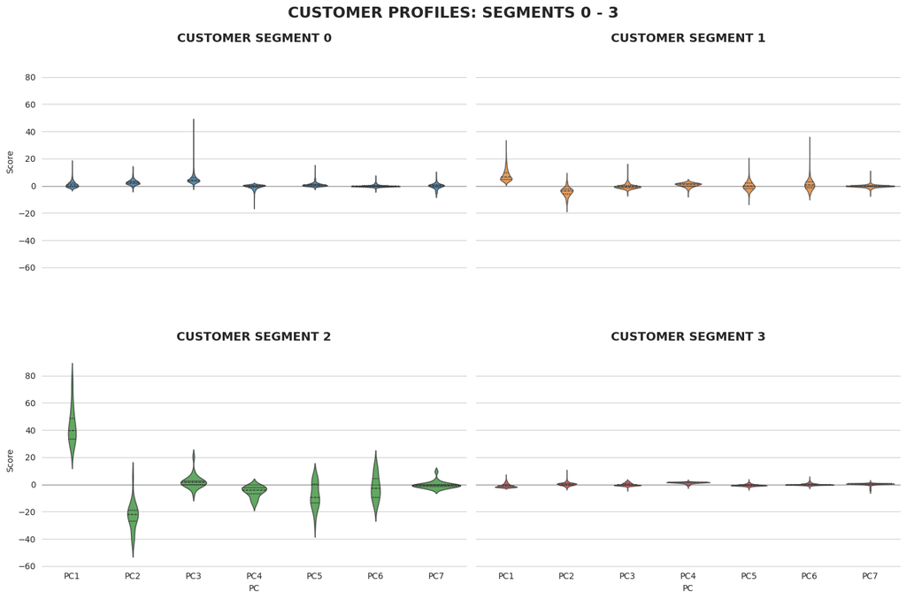

```python
df_melted_part1 = pca_df[pca_df['cluster'].isin([0, 1, 2, 3])].melt(id_vars='cluster', var_name='PC', value_name='Score')

sns.set_style("whitegrid")
g1 = sns.FacetGrid(df_melted_part1, col="cluster", col_wrap=2,
                   hue="cluster", palette="tab10", height=5, aspect=1.5)

g1.map(sns.violinplot, "PC", "Score", order=[f'PC{i}' for i in range(1, 8)],
       inner="quartile", linewidth=1.2, alpha=0.8)

for ax in g1.axes.flat:
    ax.axhline(0, ls='-', c='black', alpha=0.3, linewidth=1)
    sns.despine(ax=ax, left=True, bottom=True)
    ax.set_xticks(range(7))
    ax.set_xticklabels([f'PC{i}' for i in range(1, 8)], fontsize=10)
    curr_title = ax.get_title()
    cluster_num = curr_title.split('=')[-1].strip()
    ax.set_title(f"CUSTOMER SEGMENT {cluster_num}", fontsize=14, fontweight='bold', pad=15)

plt.subplots_adjust(top=0.90, hspace=0.4)
g1.fig.suptitle('CUSTOMER PROFILES: SEGMENTS 0 - 3', fontsize=18, fontweight='bold')

plt.savefig('customer_profiles_1.png', dpi=300)
plt.show()
```

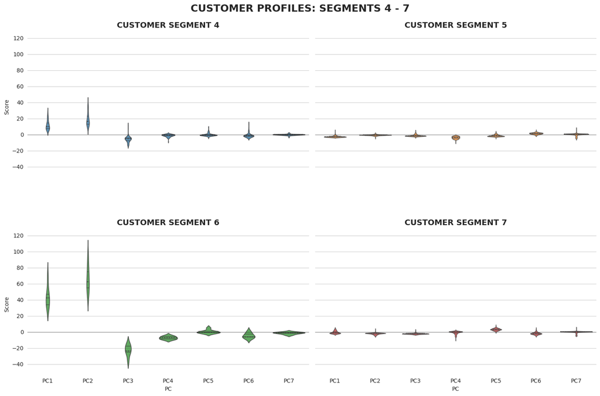

```python
df_melted_part2 = pca_df[pca_df['cluster'].isin([4, 5, 6, 7])].melt(id_vars='cluster', var_name='PC', value_name='Score')

g2 = sns.FacetGrid(df_melted_part2, col="cluster", col_wrap=2,
                   hue="cluster", palette="tab10", height=5, aspect=1.5)

g2.map(sns.violinplot, "PC", "Score", order=[f'PC{i}' for i in range(1, 8)],
       inner="quartile", linewidth=1.2, alpha=0.8)

for ax in g2.axes.flat:
    ax.axhline(0, ls='-', c='black', alpha=0.3, linewidth=1)
    sns.despine(ax=ax, left=True, bottom=True)
    ax.set_xticks(range(7))
    ax.set_xticklabels([f'PC{i}' for i in range(1, 8)], fontsize=10)
    curr_title = ax.get_title()
    cluster_num = curr_title.split('=')[-1].strip()
    ax.set_title(f"CUSTOMER SEGMENT {cluster_num}", fontsize=14, fontweight='bold', pad=15)

plt.subplots_adjust(top=0.90, hspace=0.4)
g2.fig.suptitle('CUSTOMER PROFILES: SEGMENTS 4 - 7', fontsize=18, fontweight='bold')


plt.savefig('customer_profiles_2.png', dpi=300)
plt.show()
```

```python
cluster0 = pca_df.loc[pca_df[
    'cluster'] == 0].drop('cluster', axis=1)
cluster1 = pca_df.loc[pca_df[
    'cluster'] == 1].drop('cluster', axis=1)
cluster2 = pca_df.loc[pca_df[
    'cluster'] == 2].drop('cluster', axis=1)
cluster3 = pca_df.loc[pca_df[
    'cluster'] == 3].drop('cluster', axis=1)
cluster4 = pca_df.loc[pca_df[
    'cluster'] == 4].drop('cluster', axis=1)
cluster5 = pca_df.loc[pca_df[
    'cluster'] == 5].drop('cluster', axis=1)
cluster6 = pca_df.loc[pca_df[
    'cluster'] == 6].drop('cluster', axis=1)
cluster7 = pca_df.loc[pca_df[
    'cluster'] == 7].drop('cluster', axis=1)
```

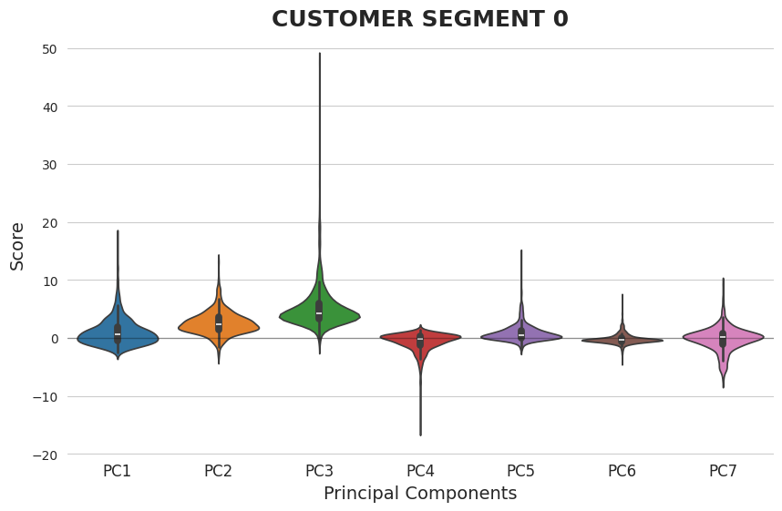

```python
plt.figure(figsize=(10, 6))

sns.violinplot(
    data=cluster0
)
plt.axhline(0, ls='-', c='black', alpha=0.3, linewidth=1)
sns.despine(left=True, bottom=True)

plt.title("CUSTOMER SEGMENT 0", fontsize=18, fontweight='bold')
plt.xticks(fontsize=12)
plt.xlabel('Principal Components', fontsize=14)
plt.ylabel('Score', fontsize=14)

plt.savefig('customer_segment_0.png', dpi=300)
plt.show()
```

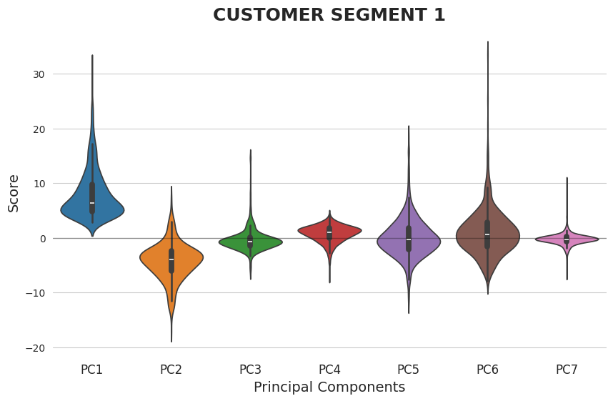

```python
plt.figure(figsize=(10, 6))

sns.violinplot(
    data=cluster1
)
plt.axhline(0, ls='-', c='black', alpha=0.3, linewidth=1)
sns.despine(left=True, bottom=True)

plt.title("CUSTOMER SEGMENT 1", fontsize=18, fontweight='bold')
plt.xticks(fontsize=12)
plt.xlabel('Principal Components', fontsize=14)
plt.ylabel('Score', fontsize=14)

plt.savefig('customer_segment_1.png', dpi=300)
plt.show()
```

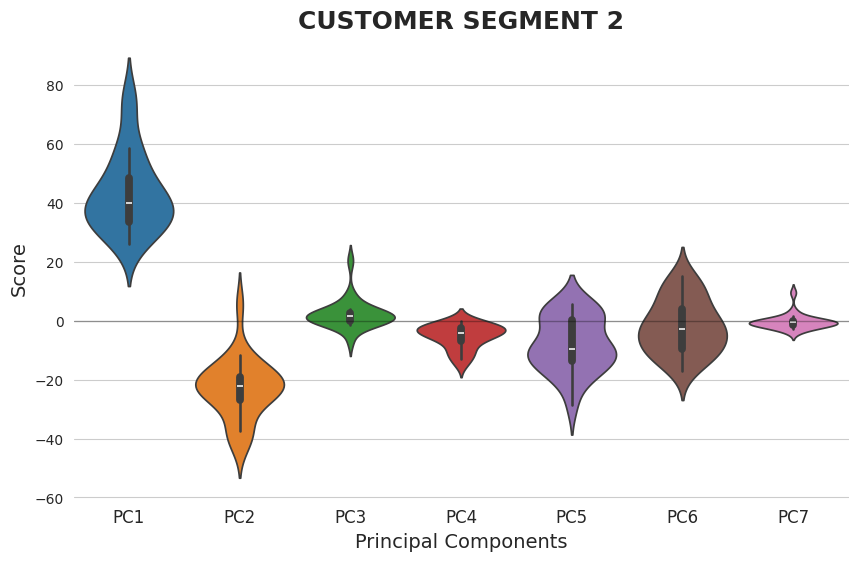

```python
plt.figure(figsize=(10, 6))

sns.violinplot(
    data=cluster2
)
plt.axhline(0, ls='-', c='black', alpha=0.3, linewidth=1)
sns.despine(left=True, bottom=True)

plt.title("CUSTOMER SEGMENT 2", fontsize=18, fontweight='bold')
plt.xticks(fontsize=12)
plt.xlabel('Principal Components', fontsize=14)
plt.ylabel('Score', fontsize=14)

plt.savefig('customer_segment_2.png', dpi=300)
plt.show()
```

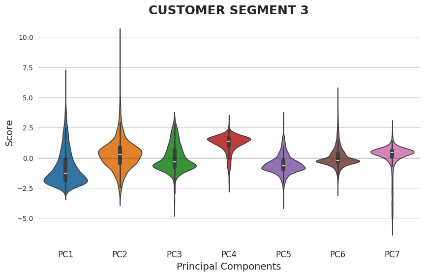

```python
plt.figure(figsize=(10, 6))

sns.violinplot(
    data=cluster3
)
plt.axhline(0, ls='-', c='black', alpha=0.3, linewidth=1)
sns.despine(left=True, bottom=True)

plt.title("CUSTOMER SEGMENT 3", fontsize=18, fontweight='bold')
plt.xticks(fontsize=12)
plt.xlabel('Principal Components', fontsize=14)
plt.ylabel('Score', fontsize=14)

plt.savefig('customer_segment_3.png', dpi=300)
plt.show()
```

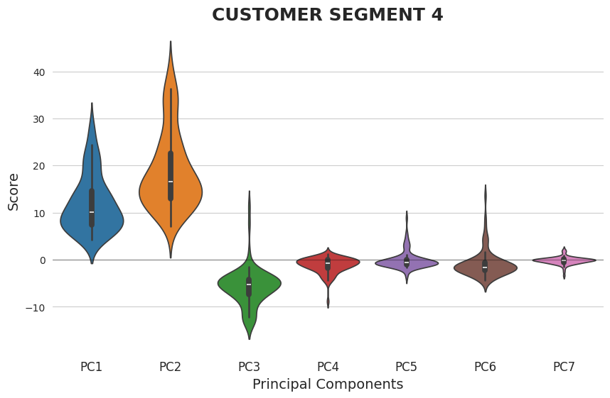

```python
plt.figure(figsize=(10, 6))

sns.violinplot(
    data=cluster4
)
plt.axhline(0, ls='-', c='black', alpha=0.3, linewidth=1)
sns.despine(left=True, bottom=True)

plt.title("CUSTOMER SEGMENT 4", fontsize=18, fontweight='bold')
plt.xticks(fontsize=12)
plt.xlabel('Principal Components', fontsize=14)
plt.ylabel('Score', fontsize=14)

plt.savefig('customer_segment_4.png', dpi=300)
plt.show()
```

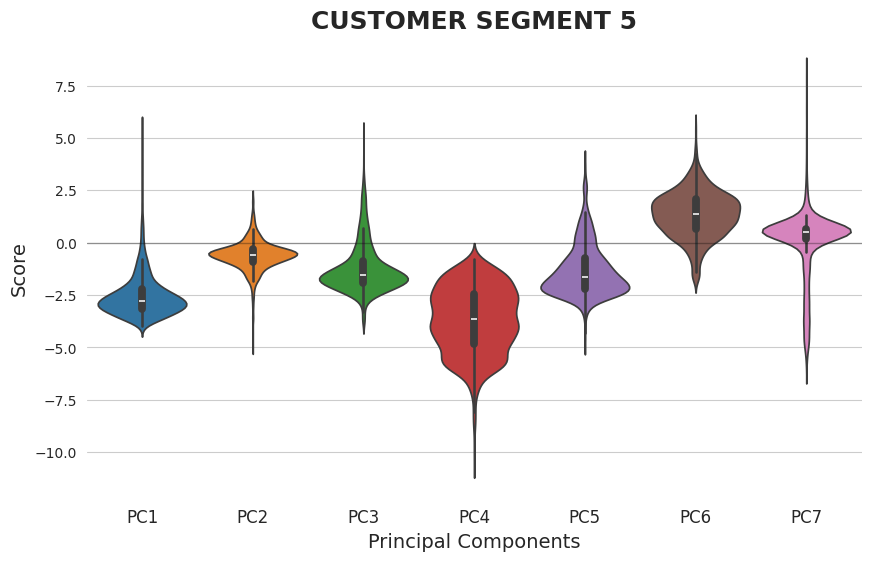

```python
plt.figure(figsize=(10, 6))

sns.violinplot(
    data=cluster5
)
plt.axhline(0, ls='-', c='black', alpha=0.3, linewidth=1)
sns.despine(left=True, bottom=True)

plt.title("CUSTOMER SEGMENT 5", fontsize=18, fontweight='bold')
plt.xticks(fontsize=12)
plt.xlabel('Principal Components', fontsize=14)
plt.ylabel('Score', fontsize=14)

plt.savefig('customer_segment_5.png', dpi=300)
plt.show()
```

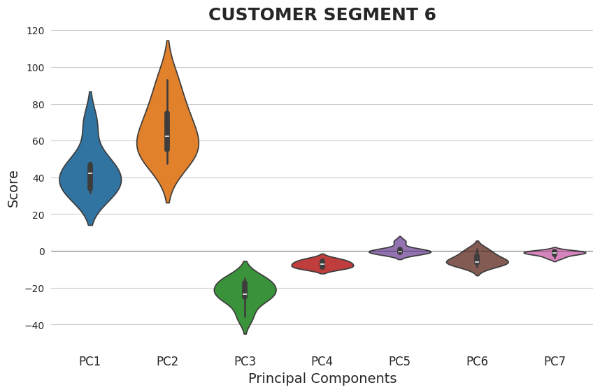

```python
plt.figure(figsize=(10, 6))

sns.violinplot(
    data=cluster6
)
plt.axhline(0, ls='-', c='black', alpha=0.3, linewidth=1)
sns.despine(left=True, bottom=True)

plt.title("CUSTOMER SEGMENT 6", fontsize=18, fontweight='bold')
plt.xticks(fontsize=12)
plt.xlabel('Principal Components', fontsize=14)
plt.ylabel('Score', fontsize=14)

plt.savefig('customer_segment_6.png', dpi=300)
plt.show()
```

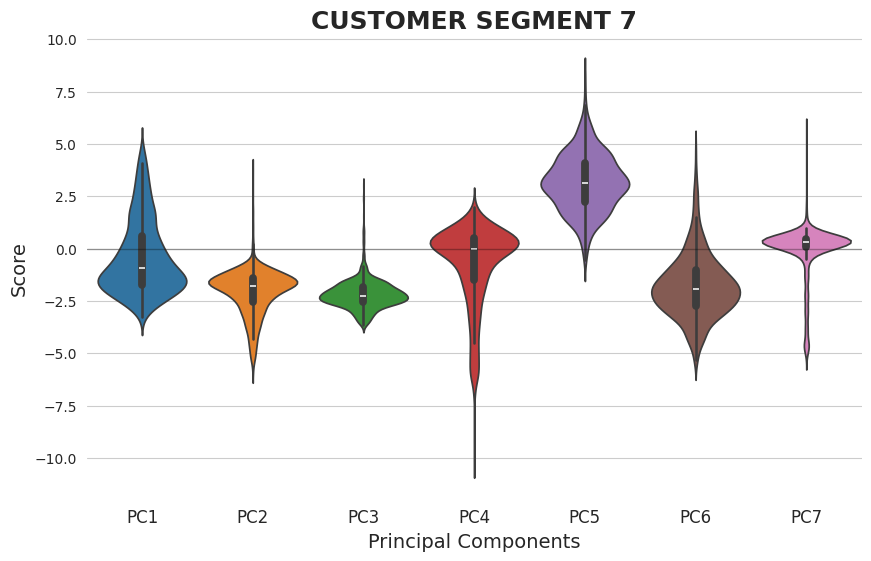

```python
plt.figure(figsize=(10, 6))

sns.violinplot(
    data=cluster7
)
plt.axhline(0, ls='-', c='black', alpha=0.3, linewidth=1)
sns.despine(left=True, bottom=True)

plt.title("CUSTOMER SEGMENT 7", fontsize=18, fontweight='bold')
plt.xticks(fontsize=12)
plt.xlabel('Principal Components', fontsize=14)
plt.ylabel('Score', fontsize=14)

plt.savefig('customer_segment_7.png', dpi=300)
plt.show()
```

# Customer Segmentation Interpretation

The clustering results reveal clear behavioral differences across customers when viewed through the seven principal components derived from PCA. Instead of relying on raw variables, each cluster reflects a combination of spending level, credit usage, repayment behavior, and customer lifecycle. This makes the segmentation more meaningful and easier to connect to real-world financial behavior.

Cluster 1 consists of moderately active customers with balanced behavior across spending and repayment. They use their cards regularly for purchases but do not rely heavily on risky features like cash advances or minimum-only payments. This group represents a stable middle segment—engaged but controlled. They are ideal candidates for upselling strategies such as gradual credit limit increases or personalized financial products.

### **Overall Conclusion**

The clustering approach successfully segments customers into meaningful behavioral groups that go beyond simple spending levels. By using PCA, the model captures deeper patterns in how customers interact with credit—ranging from disciplined usage to high-risk dependency. This segmentation provides a strong foundation for both targeted marketing strategies and effective risk management.

# Conclusion and Summary of Findings

This project set out to segment credit card customers based on their financial behavior using unsupervised machine learning. By combining feature engineering, scaling, Principal Component Analysis (PCA), and K-Means clustering, the analysis moved beyond raw transactional data to uncover structured behavioral patterns within the customer base.

A key outcome of the analysis is that customer behavior is not one-dimensional. Instead, it is driven by multiple underlying factors including spending intensity, credit dependency, repayment discipline, and account tenure. PCA was instrumental in transforming the original variables into these distinct behavioral dimensions, reducing noise and eliminating redundancy while preserving the core information in the dataset.

From a business perspective, these findings demonstrate that different customer groups require different strategies. High-value customers are best targeted with retention and rewards programs, while inactive users need engagement and activation efforts. Credit-dependent and high-risk segments require closer monitoring and risk controls, whereas disciplined users contribute to portfolio stability despite generating less interest revenue. This reinforces the importance of segmentation as a tool for both revenue optimization and risk management.

Overall, the project shows that clustering, when combined with proper preprocessing and dimensionality reduction, can effectively uncover meaningful customer segments in financial data. The resulting insights provide a practical foundation for decision-making in areas such as marketing, customer retention, credit policy, and risk assessment.